# Supervised Learning - Foundations Project: ReCell

### Bivariate Analysis

- used to answer questions .....

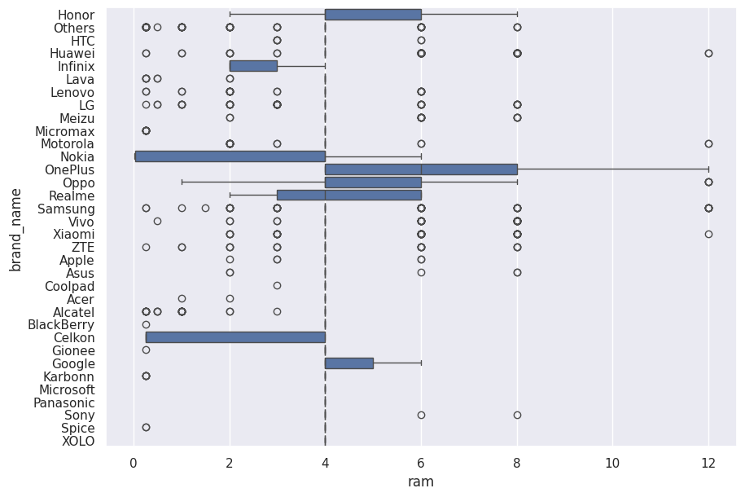

```python
#question 3 ram v. brand
plt.figure(figsize=(10,7))
sns.boxplot(cell, x='ram', y='brand_name')
plt.show()
```

**Response to Question 3:** The most desired, and common, RAM is 4GB. The Brands "OnePlus" and "Google" are extraordinary, as these phones' lowest RAM quality is 4. "Celkon" brand has 4GB of RAM as their highest quality.

```
(341, 15)
```

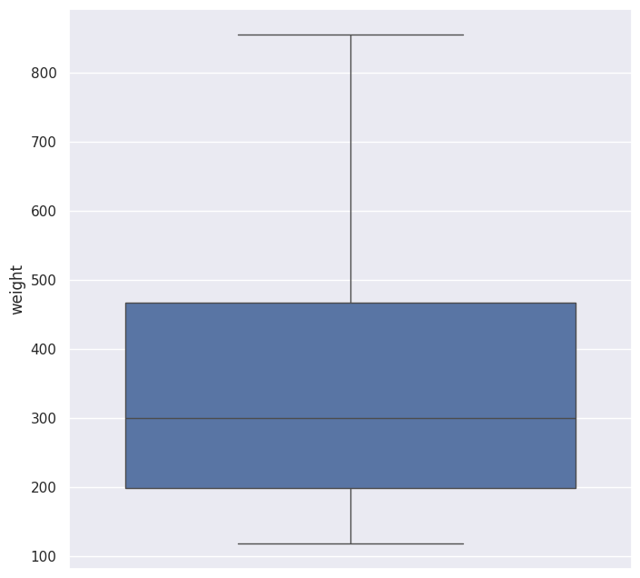

```python
#large batteries question 4
#dataframe of desired battery size
battery_4500 = cell[cell.battery > 4500]

#check size of new dataframe
print(battery_4500.shape)

#visualize large batteries' weight
plt.figure(figsize=(8,8))
sns.boxplot(battery_4500, y= 'weight')
```

Response to Question 4: Phones/Tablets with larger batteries have a weight distribution that is skewed right, as the tail of our boxplot is stretched. This tells us that the IQR (inner 50% of large battery data) displays wieghts between 200-470 grams

```
(1099, 15)
```

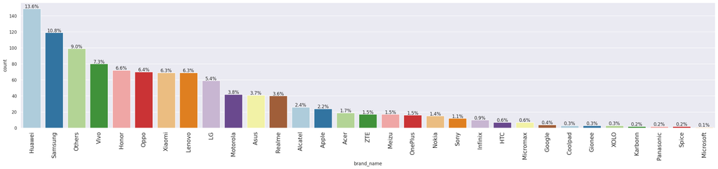

```python
#screen size question 5
#focus on screens greater than 6 INCHES
## must convert cm to inches, multiply
screen_6in = cell[cell.screen_size > 6 * 2.54]

#check size of new dataframe
print(screen_6in.shape)
#visualize large screens' brand
labeled_bar(screen_6in,'brand_name')
```

**Response to Question 5:** Huawei brand has 13% of the cell phones in the datafram with screens of larger size. Brands such as: Microsoft, Spice, Panasonic,Karbonn, XOLO..., Infinix each have less than 1% of their phones with large screensizes.

```
(655, 15)
```

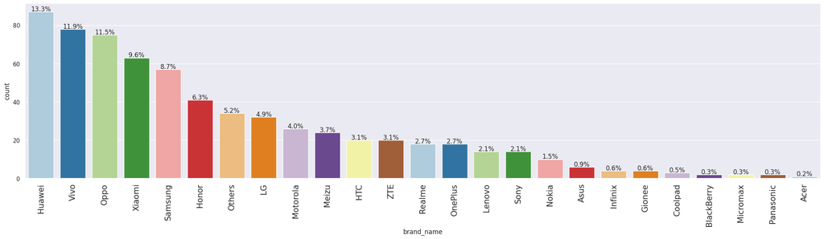

```python
#question 6 selfie czmera and brand
good_selfie = cell[cell.selfie_camera_mp>8]
#check size of new dataframe
print(good_selfie.shape)
#visualize large screens' brand
labeled_bar(good_selfie,'brand_name')
```

**Response to Question 6:** Note that the brand leading in larger screen sizes also dominates the Selfie_camer_mp category (Huawei)! The first five brands of the barplot (Huawei, Vivo, Oppo, Xiaomi, Samsung) dominate the selfi feild with 55% of the high-quality selfie cameras attributed to these brands.

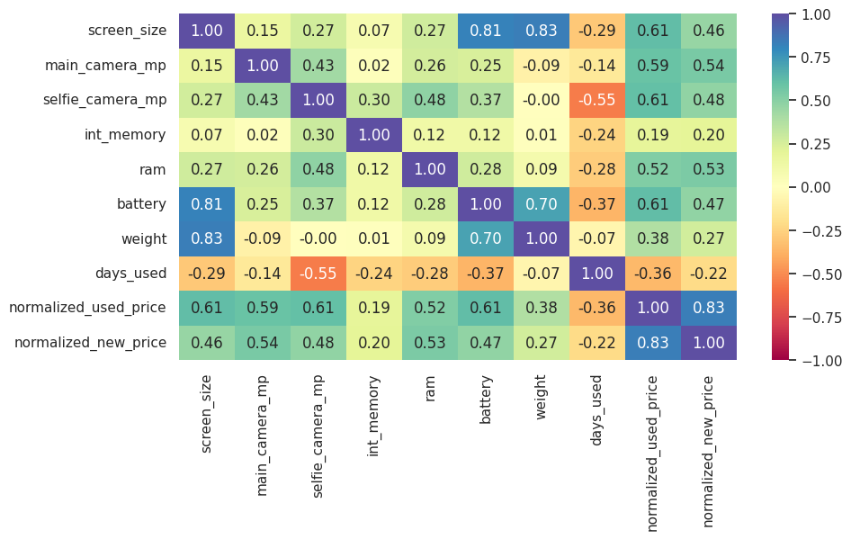

```python
#question 7 correlation to used price

#copy data
cell_copy = cell.copy()
#excuse categorical columns from data
numeric_cell_features = cell_copy.drop(['release_year', 'brand_name', 'os', '4g','5g'], axis=1)
#create list of numeric columns to apply to heatmap
list_numeric = numeric_cell_features.columns.tolist()

#create heatmap
plt.figure(figsize=(10,5))
sns.heatmap(numeric_cell_features[list_numeric].corr(), annot = True, vmin=-1, vmax=1, fmt='.2f',cmap='Spectral')
plt.show()
```

Response to Question 7: Predictors variables that are highly correlated to Normalized_used_price are as follows:

1. normalized_new_price has a correlation of 0.83 (highest). This tells us customers pay a higher amount due to the original price of a cell phone.
2. selfie_camera_mp, battery, screen_size all have correlation of 0.61 (three-way tie). This tells us that customers are willing to pay more for enhanced selfie experiences, battery life, and larger screen sizes.
3. With a correlation of -0.36, (days_used) customers will pay less for a phone that has been used more by a previous party. We can better understand this predictor when we know the total age of the phone. Days_used might correspond to the overall age of the cell phone in years, rather than how long it was used for.

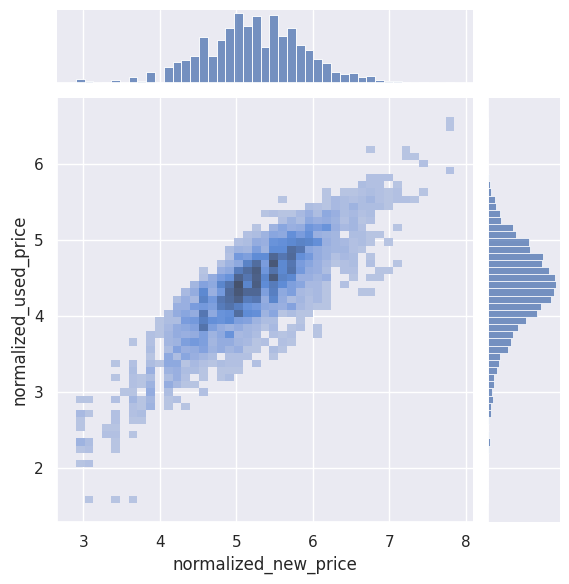

```python
#visualize high relationship between new and used prices
sns.jointplot(cell, x='normalized_new_price', y='normalized_used_price', kind='hist')
plt.show()
```

The histograms of the two monetary units are quite similar, with a strong positive trend. It seems that a phone originally priced around 5-6 euros will likely sell for 4-5 euros. The original price of the phone is a significant predictor to how much it will sell for.

## Data Preprocessing

- Missing value treatment
- Feature engineering (if needed)
- Outlier detection and treatment (if needed)
- Preparing data for modeling
- Any other preprocessing steps (if needed)

### Missing values

From the data overview, we are aware that there are some missing cells. We also know from oour visualizations that there may be extreme vallues in some categories. As such, we will fill missing data using the median value of a column. To be as specific as possible, we will sort and fill our missing data based on the Brand and Release year.

```python
#copy data to avoid changes
df = cell.copy()
```

```python
df.isnull().sum()
```

```
brand_name                 0
os                         0
screen_size                0
4g                         0
5g                         0
main_camera_mp           179
selfie_camera_mp           2
int_memory                 4
ram                        4
battery                    6
weight                     7
release_year               0
days_used                  0
normalized_used_price      0
normalized_new_price       0
dtype: int64
```

```python
#replace missing values with medians by grouping
df['main_camera_mp'] = df['main_camera_mp'].fillna(
    value = df.groupby(['brand_name','release_year'])['main_camera_mp'].transform('median'))
df['selfie_camera_mp'] = df['selfie_camera_mp'].fillna(
    value = df.groupby(['brand_name','release_year'])['selfie_camera_mp'].transform('median'))
df['int_memory'] = df['int_memory'].fillna(
    value = df.groupby(['brand_name','release_year'])['int_memory'].transform('median'))
df['ram'] = df['ram'].fillna(
    value = df.groupby(['brand_name','release_year'])['ram'].transform('median'))
df['battery'] = df['battery'].fillna(
    value = df.groupby(['brand_name','release_year'])['battery'].transform('median'))
df['weight'] = df['weight'].fillna(
    value = df.groupby(['brand_name','release_year'])['weight'].transform('median'))

df.isnull().sum()
```

```
brand_name                 0
os                         0
screen_size                0
4g                         0
5g                         0
main_camera_mp           179
selfie_camera_mp           2
int_memory                 0
ram                        0
battery                    6
weight                     7
release_year               0
days_used                  0
normalized_used_price      0
normalized_new_price       0
dtype: int64
```

```python
#values still missing will be replaced using only brand name
df['main_camera_mp'] = df['main_camera_mp'].fillna(
    value = df.groupby(['brand_name'])['main_camera_mp'].transform('median'))

df['selfie_camera_mp'] = df['selfie_camera_mp'].fillna(
    value = df.groupby(['brand_name'])['selfie_camera_mp'].transform('median'))

df['battery'] = df['battery'].fillna(
    value = df.groupby(['brand_name'])['battery'].transform('median'))

df['weight'] = df['weight'].fillna(
    value = df.groupby(['brand_name'])['weight'].transform('median'))
#check missing
df.isnull().sum()
```

```
brand_name                0
os                        0
screen_size               0
4g                        0
5g                        0
main_camera_mp           10
selfie_camera_mp          0
int_memory                0
ram                       0
battery                   0
weight                    0
release_year              0
days_used                 0
normalized_used_price     0
normalized_new_price      0
dtype: int64
```

```python
#impute median of main camera column for final missing entries
df['main_camera_mp'] = df['main_camera_mp'].fillna(df.main_camera_mp.median())
#check missing
df.isnull().sum()
```

```
brand_name               0
os                       0
screen_size              0
4g                       0
5g                       0
main_camera_mp           0
selfie_camera_mp         0
int_memory               0
ram                      0
battery                  0
weight                   0
release_year             0
days_used                0
normalized_used_price    0
normalized_new_price     0
dtype: int64
```

### Feature Engineering

- As noted in the problem statement, the phones in our data were collected in 2021. We can use this information to calculate the age of the used cell phones. This feature will likely help understand how the Used Price may be affected as a phone gets further from its release date.
- We will drop the Brand_Name of phones from our dataframe as these will not serve for linear regression equation

```python
#calculate age column
df['years_old'] = 2021 - df['release_year']

#check dataframe
df.tail()
```

|  | brand_name | os | screen_size | 4g | 5g | main_camera_mp | selfie_camera_mp | int_memory | ram | battery | weight | release_year | days_used | normalized_used_price | normalized_new_price | years_old |
| --- | --- | --- | --- | --- | --- | --- | --- | --- | --- | --- | --- | --- | --- | --- | --- | --- |
| 3449 | Asus | Android | 15.34 | yes | no | 13.0 | 8.0 | 64.0 | 6.0 | 5000.0 | 190.0 | 2019 | 232 | 4.492337 | 6.483872 | 2 |
| 3450 | Asus | Android | 15.24 | yes | no | 13.0 | 8.0 | 128.0 | 8.0 | 4000.0 | 200.0 | 2018 | 541 | 5.037732 | 6.251538 | 3 |
| 3451 | Alcatel | Android | 15.80 | yes | no | 13.0 | 5.0 | 32.0 | 3.0 | 4000.0 | 165.0 | 2020 | 201 | 4.357350 | 4.528829 | 1 |
| 3452 | Alcatel | Android | 15.80 | yes | no | 13.0 | 5.0 | 32.0 | 2.0 | 4000.0 | 160.0 | 2020 | 149 | 4.349762 | 4.624188 | 1 |
| 3453 | Alcatel | Android | 12.83 | yes | no | 13.0 | 5.0 | 16.0 | 2.0 | 4000.0 | 168.0 | 2020 | 176 | 4.132122 | 4.279994 | 1 |

```python
#remove release year column
df.drop('release_year', axis=1, inplace=True)
```

```python
#remove brand name column
df.drop('brand_name', axis=1, inplace=True)
```

### Outlier Detection

If outliers exist, we will check if they heavily impact the data (outrageous values). Else, they will be considered proper values.

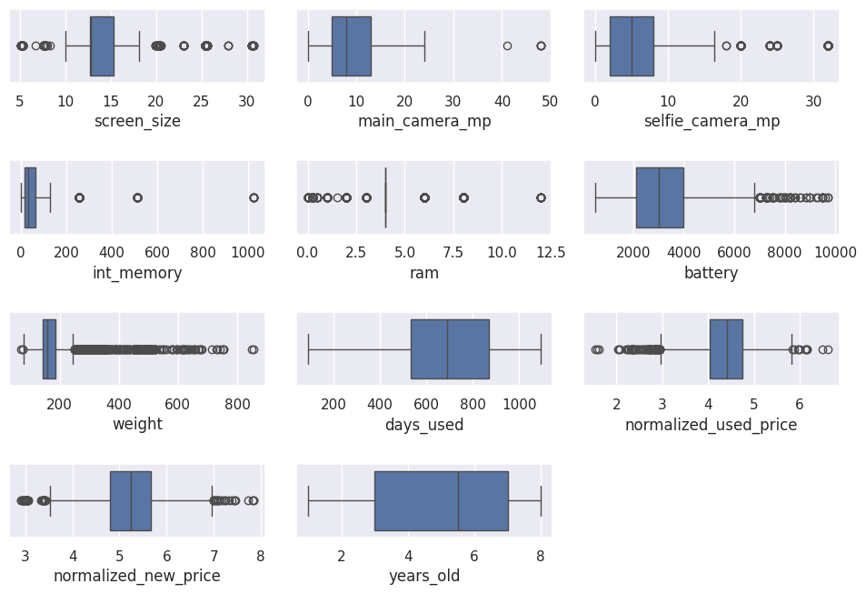

```python
# outlier detection using boxplot
num_cols = df.select_dtypes(include=np.number).columns.tolist()

plt.figure(figsize=(10, 7))

for i, variable in enumerate(num_cols):
    plt.subplot(4, 3, i + 1)
    sns.boxplot(data=df, x=variable)
    plt.tight_layout(pad=2)

plt.show()
```

- int_memory has a large value of 1000. however, a quick online search will tell you that phones with 1TB of memory do exist on the market, we will not delete this from our data.
- The outliers seen for main_camera_mp and selfie_camera_mp are similar and not ridiculously large, we will not remove them from our data as they are proper values. -Overall, we will not treat any outliers in the data as they are proper for the market of phones/tablets from many years of technology advancements.

### Data Prep

Problem Statement asks for prediction of Normalized Used Price of cell phones for the ReCell company.

- Dependent Variable (y) = normalized_used_price
- Independent Variables (x) = os, 4g/5g, main_camera_mp, selfie_camera_mp, int_memory, ram, battery, weight, days_used, normalized_new_price

  Note: Os and 4g, 5g are categorical variables. We will need to make dummy variables. We will have a column that describes yes/no for OS as well as 4G vs 5G.

```python
#declare X and y
X = df.drop('normalized_used_price', axis=1)
y = df['normalized_used_price']
```

```python
#add y intercept to data
X = sm.add_constant(X)
```

```python
#create dummy variables
X = pd.get_dummies(
    X,
    columns=X.select_dtypes(include=["object", "category"]).columns.tolist(),
    drop_first=True,
)
X.head()
```

|  | const | screen_size | main_camera_mp | selfie_camera_mp | int_memory | ram | battery | weight | days_used | normalized_new_price | years_old | os_Others | os_Windows | os_iOS | 4g_yes | 5g_yes |
| --- | --- | --- | --- | --- | --- | --- | --- | --- | --- | --- | --- | --- | --- | --- | --- | --- |
| 0 | 1.0 | 14.50 | 13.0 | 5.0 | 64.0 | 3.0 | 3020.0 | 146.0 | 127 | 4.715100 | 1 | False | False | False | True | False |
| 1 | 1.0 | 17.30 | 13.0 | 16.0 | 128.0 | 8.0 | 4300.0 | 213.0 | 325 | 5.519018 | 1 | False | False | False | True | True |
| 2 | 1.0 | 16.69 | 13.0 | 8.0 | 128.0 | 8.0 | 4200.0 | 213.0 | 162 | 5.884631 | 1 | False | False | False | True | True |
| 3 | 1.0 | 25.50 | 13.0 | 8.0 | 64.0 | 6.0 | 7250.0 | 480.0 | 345 | 5.630961 | 1 | False | False | False | True | True |
| 4 | 1.0 | 15.32 | 13.0 | 8.0 | 64.0 | 3.0 | 5000.0 | 185.0 | 293 | 4.947837 | 1 | False | False | False | True | False |

```python
#fix Boolean data types
X = X.astype(float)
X.head(10)
```

|  | const | screen_size | main_camera_mp | selfie_camera_mp | int_memory | ram | battery | weight | days_used | normalized_new_price | years_old | os_Others | os_Windows | os_iOS | 4g_yes | 5g_yes |
| --- | --- | --- | --- | --- | --- | --- | --- | --- | --- | --- | --- | --- | --- | --- | --- | --- |
| 0 | 1.0 | 14.50 | 13.0 | 5.0 | 64.0 | 3.0 | 3020.0 | 146.0 | 127.0 | 4.715100 | 1.0 | 0.0 | 0.0 | 0.0 | 1.0 | 0.0 |
| 1 | 1.0 | 17.30 | 13.0 | 16.0 | 128.0 | 8.0 | 4300.0 | 213.0 | 325.0 | 5.519018 | 1.0 | 0.0 | 0.0 | 0.0 | 1.0 | 1.0 |
| 2 | 1.0 | 16.69 | 13.0 | 8.0 | 128.0 | 8.0 | 4200.0 | 213.0 | 162.0 | 5.884631 | 1.0 | 0.0 | 0.0 | 0.0 | 1.0 | 1.0 |
| 3 | 1.0 | 25.50 | 13.0 | 8.0 | 64.0 | 6.0 | 7250.0 | 480.0 | 345.0 | 5.630961 | 1.0 | 0.0 | 0.0 | 0.0 | 1.0 | 1.0 |
| 4 | 1.0 | 15.32 | 13.0 | 8.0 | 64.0 | 3.0 | 5000.0 | 185.0 | 293.0 | 4.947837 | 1.0 | 0.0 | 0.0 | 0.0 | 1.0 | 0.0 |
| 5 | 1.0 | 16.23 | 13.0 | 8.0 | 64.0 | 4.0 | 4000.0 | 176.0 | 223.0 | 5.060694 | 1.0 | 0.0 | 0.0 | 0.0 | 1.0 | 0.0 |
| 6 | 1.0 | 13.84 | 8.0 | 5.0 | 32.0 | 2.0 | 3020.0 | 144.0 | 234.0 | 4.518958 | 1.0 | 0.0 | 0.0 | 0.0 | 1.0 | 0.0 |
| 7 | 1.0 | 15.77 | 13.0 | 8.0 | 64.0 | 4.0 | 3400.0 | 164.0 | 219.0 | 5.188726 | 1.0 | 0.0 | 0.0 | 0.0 | 1.0 | 0.0 |
| 8 | 1.0 | 15.32 | 13.0 | 16.0 | 128.0 | 6.0 | 4000.0 | 165.0 | 161.0 | 5.299916 | 1.0 | 0.0 | 0.0 | 0.0 | 1.0 | 0.0 |
| 9 | 1.0 | 16.23 | 13.0 | 8.0 | 128.0 | 6.0 | 4000.0 | 176.0 | 327.0 | 5.073610 | 1.0 | 0.0 | 0.0 | 0.0 | 1.0 | 0.0 |

```python
# splitting the data in 70:30 ratio for train to test data
x_train, x_test, y_train, y_test = train_test_split(X, y, test_size=0.3, random_state=1)
```

```python
#look at train and test
print("Number of rows in train data =", x_train.shape[0])
print("Number of rows in test data =", x_test.shape[0])
```

```
Number of rows in train data = 2417
Number of rows in test data = 1037
```

## EDA

- It is a good idea to explore the data once again after manipulating it.

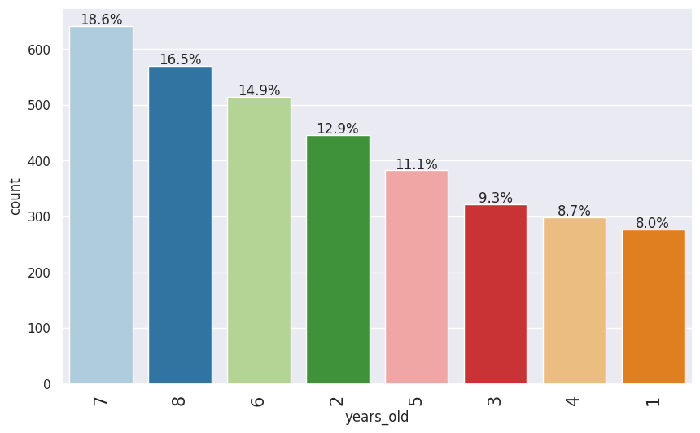

```python
#barplot years old
labeled_bar(df, 'years_old')
```

Now that we understand the age of phones, we can see that the most common phones in the ReCell inventory are 6-8 years old (50% of data). This shows us that ReCell's inventory does not offer as many phones for buyers that are looking for something more contemporary; there are only 20.9% of phones that are 1-2 years old.

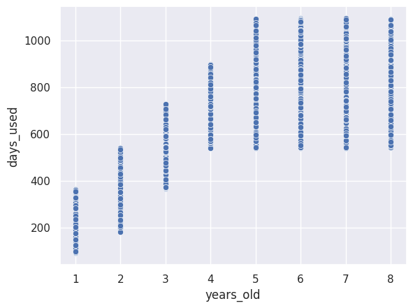

```python
#years vs days used boxplots
sns.scatterplot(df, x='years_old', y='days_used')
```

As would be expected, the older a phone's age (years), the more days it has been used by a previous owner. It is interesting to note, however, that there is a large spread of days_used even when the phone is only a ear old. This means that some of ReCell's inventory contains phones that have hardly been used. These are likely high value of used price.

## Model Building - Linear Regression

```python
#build our first regression model
olsmodel = sm.OLS(y_train, x_train).fit()
print(olsmodel.summary())
```

```
                              OLS Regression Results
=================================================================================
Dep. Variable:     normalized_used_price   R-squared:                       0.842
Model:                               OLS   Adj. R-squared:                  0.841
Method:                    Least Squares   F-statistic:                     850.5
Date:                   Fri, 10 May 2024   Prob (F-statistic):               0.00
Time:                           23:48:04   Log-Likelihood:                 98.614
No. Observations:                   2417   AIC:                            -165.2
Df Residuals:                       2401   BIC:                            -72.58
Df Model:                             15
Covariance Type:               nonrobust
========================================================================================
                           coef    std err          t      P>|t|      [0.025      0.975]
----------------------------------------------------------------------------------------
const                    1.3703      0.053     25.926      0.000       1.267       1.474
screen_size              0.0254      0.003      7.636      0.000       0.019       0.032
main_camera_mp           0.0209      0.001     14.822      0.000       0.018       0.024
selfie_camera_mp         0.0139      0.001     12.867      0.000       0.012       0.016
int_memory            9.782e-05   6.69e-05      1.461      0.144   -3.34e-05       0.000
ram                      0.0205      0.005      4.110      0.000       0.011       0.030
battery              -1.294e-05   7.09e-06     -1.826      0.068   -2.68e-05    9.57e-07
weight                   0.0009      0.000      7.175      0.000       0.001       0.001
days_used             4.651e-05   3.05e-05      1.526      0.127   -1.33e-05       0.000
normalized_new_price     0.4215      0.011     37.277      0.000       0.399       0.444
years_old               -0.0255      0.004     -5.730      0.000      -0.034      -0.017
os_Others               -0.0486      0.029     -1.651      0.099      -0.106       0.009
os_Windows               0.0266      0.036      0.732      0.464      -0.045       0.098
os_iOS                  -0.0619      0.045     -1.385      0.166      -0.150       0.026
4g_yes                   0.0477      0.015      3.129      0.002       0.018       0.078
5g_yes                  -0.0504      0.031     -1.635      0.102      -0.111       0.010
==============================================================================
Omnibus:                      236.533   Durbin-Watson:                   1.909
Prob(Omnibus):                  0.000   Jarque-Bera (JB):              461.165
Skew:                          -0.639   Prob(JB):                    7.23e-101
Kurtosis:                       4.716   Cond. No.                     4.10e+04
==============================================================================

Notes:
[1] Standard Errors assume that the covariance matrix of the errors is correctly specified.
[2] The condition number is large, 4.1e+04. This might indicate that there are
strong multicollinearity or other numerical problems.
```

Interpretation of Regression Results:

1. **Adjusted. R-squared**: It reflects the fit of the model.
   - the value for adj. R-squared is **0.841**, which is a strong value.
   - We may want to be cautious of over-fitting, our Performance/Assumption checks may help us to better understand this value.
1. *const* coefficient: Y-intercept of regression equation.
   - the value for `const` coefficient is **1.3703**
1. **Coefficient of a predictor variable**: It represents the change in the output Y due to a change in a given predictor variable
   - Example: the coefficient of `normalized_new_price` is **0.4215** tells us that the more expensive the cell phone was when it was first sold, the more value we will see for its `normalized_used_price`.

## Model Performance Check

```python
# function to compute adjusted R-squared
def adj_r2_score(predictors, targets, predictions):
    r2 = r2_score(targets, predictions)
    n = predictors.shape[0]
    k = predictors.shape[1]
    return 1 - ((1 - r2) * (n - 1) / (n - k - 1))

# function to compute MAPE
def mape_score(targets, predictions):
    return np.mean(np.abs(targets - predictions) / targets) * 100
```

```python
# function to compute different metrics to check performance of a regression model
def model_performance_regression(model, predictors, target):
    """
    Function to compute different metrics to check regression model performance

    model: regressor
    predictors: independent variables
    target: dependent variable
    """

    # predicting using the independent variables
    pred = model.predict(predictors)

    r2 = r2_score(target, pred)  # to compute R-squared
    adjr2 = adj_r2_score(predictors, target, pred)  # to compute adjusted R-squared
    rmse = np.sqrt(mean_squared_error(target, pred))  # to compute RMSE
    mae = mean_absolute_error(target, pred)  # to compute MAE
    mape = mape_score(target, pred)  # to compute MAPE

    # creating a dataframe of metrics
    df_performance = pd.DataFrame(
        {
            "RMSE": rmse,
            "MAE": mae,
            "R-squared": r2,
            "Adj. R-squared": adjr2,
            "MAPE": mape,
        },
        index=[0],
    )

    return df_performance
```

```python
# checking model performance on train set (seen 70% data)
print("Training Performance\n")
olsmodel_train_perf = model_performance_regression(olsmodel, x_train, y_train)
olsmodel_train_perf
```

```
Training Performance
```

|  | RMSE | MAE | R-squared | Adj. R-squared | MAPE |
| --- | --- | --- | --- | --- | --- |
| 0 | 0.232297 | 0.18226 | 0.841612 | 0.840556 | 4.377609 |

```python
# checking model performance on test set (seen 30% data)
print("Test Performance\n")
olsmodel_test_perf = model_performance_regression(olsmodel, x_test, y_test)
olsmodel_test_perf
```

```
Test Performance
```

|  | RMSE | MAE | R-squared | Adj. R-squared | MAPE |
| --- | --- | --- | --- | --- | --- |
| 0 | 0.236589 | 0.183001 | 0.844808 | 0.842374 | 4.467715 |

Performance Observations:

- The training $R^2$ is 0.8416, this high value shows us that the model is not underfitting.
- The train and test RMSE and MAE are comparable (RMSE: train 0.232; test 0.236) (MAE: train 0.182, test 0.183), so the model is not overfitting either
- MAE suggests that the model can predict normalized used prices within a mean error of 0.183 on the test data. This is great!
- MAPE of 4.5% on the test data means that we are able to predict within approx. 4.5% of Normalized Used Price of ReCell phones.

## Checking Linear Regression Assumptions

- In order to make statistical inferences from a linear regression model, it is important to ensure that the assumptions of linear regression are satisfied.

Assumptions to check:

1. Multicollinearity (routinely check VIF and p-values). To remove correlation between two or more independent variables, we will drop one variable at a time as needed.
2. Linearity / Independence (compare plot of fitted vs residuals). To deal with non-linearity, we may transofrm variables as per their relationship to the dependent variable. We will take this course of action if our plot displays a non-linear pattern.
3. Normality (histogram, QQ plot, shapiro test). We can use visual cues to best infer normality. If our data is not *perfectly* normal, it is likely okay. We simply don't want to observe any patterns that don't let us assume this course of action.
4. Homoscedasticity (goldfeldquandt test). To deal with hetersoscedasticity, we may have to identify the cause of a funnel-shapped pattern to a residual variance plot. This will only occur if our statisttical test provides a p-value < 0.05.

### Multicollinearity Checks / Resolution Processes

- VIF score 1-5 good
- VIF score 5-10 moderate collinearity -VIF score 10+ high collinearity

```python
#create function to check VIF

from statsmodels.stats.outliers_influence import variance_inflation_factor


def checking_vif(predictors):
    vif = pd.DataFrame()
    vif["feature"] = predictors.columns

    # calculate VIF for each feature
    vif["VIF"] = [
        variance_inflation_factor(predictors.values, i)
        for i in range(len(predictors.columns))
    ]
    return vif
```

```python
#apply function
checking_vif(x_train)
```

|  | feature | VIF |
| --- | --- | --- |
| 0 | const | 124.287701 |
| 1 | screen_size | 7.245006 |
| 2 | main_camera_mp | 1.996930 |
| 3 | selfie_camera_mp | 2.575590 |
| 4 | int_memory | 1.247856 |
| 5 | ram | 2.117161 |
| 6 | battery | 3.848932 |
| 7 | weight | 6.127196 |
| 8 | days_used | 2.578113 |
| 9 | normalized_new_price | 2.632565 |
| 10 | years_old | 4.627080 |
| 11 | os_Others | 1.484575 |
| 12 | os_Windows | 1.023364 |
| 13 | os_iOS | 1.089167 |
| 14 | 4g_yes | 2.260317 |
| 15 | 5g_yes | 1.722728 |

Observations: -Two predictor variables have moderate collinearity. 'Screen_size' & 'weight'

- This makes sense as a bigger screen would likely cause a cell phone to weigh more.

```python
#create a loop for dropping and checking

def treating_multicollinearity(predictors, target, high_vif_columns):
  '''
  this function will analyze the effect of dropping columns with high VIF.
  This is analysis will be viewed from Adj. R squared and the RMSE.

  Inputs:
  predictors are our independent variables
  target is our dependent variable (rating)
  high_vif_columns are the ones we viewed previously, may be shown to drop using this function
  '''
  #empty lists to store analysis outcomes
  adj_r2 = []
  rmse = []

  #build OLS models by dropping one high VIF column
  #store the adj r sq and rMSE
  for cols in high_vif_columns:
    #defining the new train set
    train = predictors.loc[:, ~predictors.columns.str.startswith(cols)]
    #create model
    olsmodel_check = sm.OLS(target, train).fit()
    #add analysis outcomes to our empty lists
    adj_r2.append(olsmodel_check.rsquared_adj)
    rmse.append(np.sqrt(olsmodel_check.mse_resid))

  #creat dataframe for the results
  temp = pd.DataFrame({'col': high_vif_columns, 'Adj. R-Squared after dropping col': adj_r2, 'RMSE after dropping col': rmse}).sort_values(by='Adj. R-Squared after dropping col', ascending=False)
  temp.reset_index(drop=True, inplace=True)
  return temp
```

```python
col_list = ['screen_size', 'weight']
check = treating_multicollinearity(x_train, y_train, col_list)
check
```

|  | col | Adj. R-Squared after dropping col | RMSE after dropping col |
| --- | --- | --- | --- |
| 0 | weight | 0.837274 | 0.235506 |
| 1 | screen_size | 0.836820 | 0.235834 |

Insights:

- the Adjusted R-Squared after dropping Weight column is higher than after dropping screen_size. This tells us that the model's original Adj. R-Squared is less impacted by the weight column than the screen_size column.
- We will drop the weight column and continue to check VIF / p-values of our predictor variables.

```python
col_to_drop = 'weight'
x_train2 = x_train.drop(col_to_drop, axis=1)
x_test2 = x_test.drop(col_to_drop, axis=1)

#check vif
vif = checking_vif(x_train2)
print('VIF after dropping', col_to_drop)
vif
```

```
VIF after dropping weight
```

|  | feature | VIF |
| --- | --- | --- |
| 0 | const | 107.333228 |
| 1 | screen_size | 3.402137 |
| 2 | main_camera_mp | 1.903762 |
| 3 | selfie_camera_mp | 2.541463 |
| 4 | int_memory | 1.247526 |
| 5 | ram | 2.113643 |
| 6 | battery | 3.469627 |
| 7 | days_used | 2.564951 |
| 8 | normalized_new_price | 2.626262 |
| 9 | years_old | 4.466062 |
| 10 | os_Others | 1.368072 |
| 11 | os_Windows | 1.022647 |
| 12 | os_iOS | 1.080979 |
| 13 | 4g_yes | 2.239495 |
| 14 | 5g_yes | 1.721245 |

All VIF scores are <5. We can run our model and check for high p-values.

```python
#run an updated model
olsmod2 = sm.OLS(y_train, x_train2).fit()
print(olsmod2.summary())
```

```
                              OLS Regression Results
=================================================================================
Dep. Variable:     normalized_used_price   R-squared:                       0.838
Model:                               OLS   Adj. R-squared:                  0.837
Method:                    Least Squares   F-statistic:                     888.9
Date:                   Fri, 10 May 2024   Prob (F-statistic):               0.00
Time:                           23:48:04   Log-Likelihood:                 72.978
No. Observations:                   2417   AIC:                            -116.0
Df Residuals:                       2402   BIC:                            -29.10
Df Model:                             14
Covariance Type:               nonrobust
========================================================================================
                           coef    std err          t      P>|t|      [0.025      0.975]
----------------------------------------------------------------------------------------
const                    1.2302      0.050     24.788      0.000       1.133       1.328
screen_size              0.0427      0.002     18.574      0.000       0.038       0.047
main_camera_mp           0.0187      0.001     13.453      0.000       0.016       0.021
selfie_camera_mp         0.0130      0.001     11.996      0.000       0.011       0.015
int_memory            9.002e-05   6.76e-05      1.331      0.183   -4.26e-05       0.000
ram                      0.0190      0.005      3.781      0.000       0.009       0.029
battery               3.022e-06    6.8e-06      0.444      0.657   -1.03e-05    1.64e-05
days_used             6.214e-05   3.07e-05      2.022      0.043    1.89e-06       0.000
normalized_new_price     0.4255      0.011     37.284      0.000       0.403       0.448
years_old               -0.0195      0.004     -4.424      0.000      -0.028      -0.011
os_Others                0.0106      0.029      0.370      0.712      -0.045       0.067
os_Windows               0.0335      0.037      0.913      0.361      -0.038       0.105
os_iOS                  -0.0341      0.045     -0.758      0.449      -0.122       0.054
4g_yes                   0.0372      0.015      2.427      0.015       0.007       0.067
5g_yes                  -0.0439      0.031     -1.410      0.159      -0.105       0.017
==============================================================================
Omnibus:                      222.355   Durbin-Watson:                   1.913
Prob(Omnibus):                  0.000   Jarque-Bera (JB):              416.130
Skew:                          -0.620   Prob(JB):                     4.35e-91
Kurtosis:                       4.611   Cond. No.                     3.87e+04
==============================================================================

Notes:
[1] Standard Errors assume that the covariance matrix of the errors is correctly specified.
[2] The condition number is large, 3.87e+04. This might indicate that there are
strong multicollinearity or other numerical problems.
```

We have quite a few variables that display high p-values (> 0.05). We will create a loop to routinely drop one predictor variable at a time and check the model until all p-values are < 0.05.

```python
# now we can focus on high p values of independent variables
# initial list of columns aka predictor/indepdendent variables
predictors = x_train2.copy()
cols = predictors.columns.tolist()

# setting an initial max p-value
max_p_value = 1

while len(cols) > 0:
    # defining the train set
    x_train_aux = predictors[cols]

    # fitting the model
    model = sm.OLS(y_train, x_train_aux).fit()

    # getting the p-values and the maximum p-value
    p_values = model.pvalues
    max_p_value = max(p_values)

    # name of the variable with maximum p-value
    feature_with_p_max = p_values.idxmax()

    if max_p_value > 0.05:
        cols.remove(feature_with_p_max)
    else:
        break

selected_features = cols
print(selected_features)
```

```
['const', 'screen_size', 'main_camera_mp', 'selfie_camera_mp', 'ram', 'days_used', 'normalized_new_price', 'years_old', '4g_yes']
```

Our loop dropped the following predictor variables:

- All OS dummy variables: this makes sense because the majority of our data was Andriod OS.
- 5G dummy variable
- int_memory
- battery

```python
#build new train and test using selected columns
x_train3 = x_train2[selected_features]
x_test3 = x_test2[selected_features]
```

```python
#run regression model
olsmod3 = sm.OLS(y_train, x_train3).fit()
print(olsmod3.summary())
```

```
                              OLS Regression Results
=================================================================================
Dep. Variable:     normalized_used_price   R-squared:                       0.838
Model:                               OLS   Adj. R-squared:                  0.837
Method:                    Least Squares   F-statistic:                     1556.
Date:                   Fri, 10 May 2024   Prob (F-statistic):               0.00
Time:                           23:48:04   Log-Likelihood:                 70.534
No. Observations:                   2417   AIC:                            -123.1
Df Residuals:                       2408   BIC:                            -70.96
Df Model:                              8
Covariance Type:               nonrobust
========================================================================================
                           coef    std err          t      P>|t|      [0.025      0.975]
----------------------------------------------------------------------------------------
const                    1.2451      0.045     27.547      0.000       1.157       1.334
screen_size              0.0433      0.001     28.862      0.000       0.040       0.046
main_camera_mp           0.0188      0.001     14.000      0.000       0.016       0.021
selfie_camera_mp         0.0133      0.001     12.514      0.000       0.011       0.015
ram                      0.0156      0.004      3.618      0.000       0.007       0.024
days_used             6.346e-05   3.05e-05      2.084      0.037    3.75e-06       0.000
normalized_new_price     0.4255      0.011     39.450      0.000       0.404       0.447
years_old               -0.0193      0.004     -4.486      0.000      -0.028      -0.011
4g_yes                   0.0365      0.015      2.421      0.016       0.007       0.066
==============================================================================
Omnibus:                      222.889   Durbin-Watson:                   1.914
Prob(Omnibus):                  0.000   Jarque-Bera (JB):              426.179
Skew:                          -0.614   Prob(JB):                     2.86e-93
Kurtosis:                       4.650   Cond. No.                     6.87e+03
==============================================================================

Notes:
[1] Standard Errors assume that the covariance matrix of the errors is correctly specified.
[2] The condition number is large, 6.87e+03. This might indicate that there are
strong multicollinearity or other numerical problems.
```

All p values below alpha. Our R-Squared and Adjusted R-Squared are comparable to our previous regression model (see olsmod2), so our fit has not been impacted. We can move forward to check model performance.

```python
#check model performance
print('Performance on the Training Data\n')
olsmod3_train_performance = model_performance_regression(olsmod3, x_train3, y_train)
olsmod3_train_performance
```

```
Performance on the Training Data
```

|  | RMSE | MAE | R-squared | Adj. R-squared | MAPE |
| --- | --- | --- | --- | --- | --- |
| 0 | 0.235011 | 0.184164 | 0.837889 | 0.837283 | 4.417875 |

```python
print('Performance on the Testing Data\n')
olsmod3_test_performance = model_performance_regression(olsmod3, x_test3, y_test)
olsmod3_test_performance
```

```
Performance on the Testing Data
```

|  | RMSE | MAE | R-squared | Adj. R-squared | MAPE |
| --- | --- | --- | --- | --- | --- |
| 0 | 0.238672 | 0.184313 | 0.842064 | 0.84068 | 4.491491 |

### Linearity / Indepdendence Check

- We desire to see NO pattern when plotting the Fitted values with Residuals.

```python
# linearity and independence
# create dataframe with actual, fitted and residual values
df_predictions = pd.DataFrame()

df_predictions["Actual Values"] = y_train  #real dependent values
df_predictions["Fitted Values"] = olsmod3.fittedvalues  # predicted values from regression
df_predictions["Residuals"] = olsmod3.resid  # residuals/differences

df_predictions.head()
```

|  | Actual Values | Fitted Values | Residuals |
| --- | --- | --- | --- |
| 3026 | 4.087488 | 3.864746 | 0.222741 |
| 1525 | 4.448399 | 4.571687 | -0.123288 |
| 1128 | 4.315353 | 4.284426 | 0.030926 |
| 3003 | 4.282068 | 4.258956 | 0.023112 |
| 2907 | 4.456438 | 4.451207 | 0.005231 |

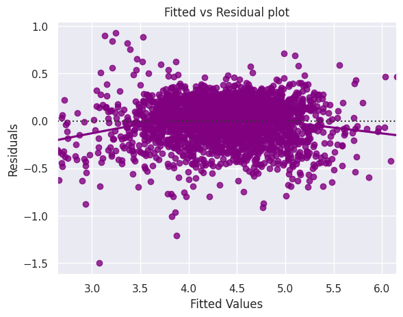

```python
# plot these fitted and residuals to make sure there is no pattern.
# we should see a blob!

sns.residplot(
    data=df_predictions, x="Fitted Values", y="Residuals", color="purple", lowess=True)
plt.xlabel("Fitted Values")
plt.ylabel("Residuals")
plt.title("Fitted vs Residual plot")
plt.show()
```

We observe no alarming pattern that would cause us to deny a linear relationship / independence of variables. Note: a pairplot can be created to further prove this point

### Normality Check

- Histogram to understand shape, we desire to see a bell curve
- QQ Plot to understand tails of our histogram / density curve
- Shapiro Test to finalize results

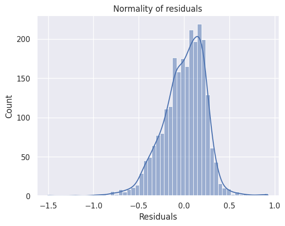

```python
#check for visual bell curve
sns.histplot(data=df_predictions, x="Residuals", kde=True)
plt.title("Normality of residuals")
plt.show()
```

Our histogram shows something close to a bell curve. We will delve further with a QQ plot

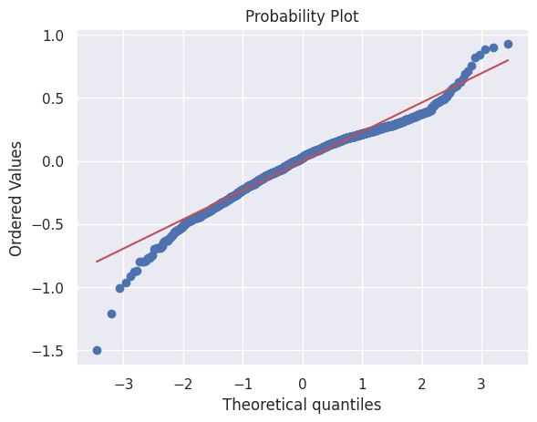

```python
#bell understand approximate bell shape seen above
import pylab
import scipy.stats as stats

stats.probplot(df_predictions["Residuals"], dist="norm", plot=pylab)
plt.show()
```

```python
#final investigation of normality
#tails are a little iffy, we can use shapiro
test_stat, p_value = stats.shapiro(df_predictions['Residuals'])
print(p_value)
```

```
1.2969799215209546e-21
```

So far the tails of our curve are not perfectly normal; this is proven by a p-value < 0.05 in our Shapiro test. *However*, we are *not* seeing an intense pattern of something like Chi-Square, Bimodal, Exponential, Log/Power distribtuions of our Residuals.

- *This allows us to hold an assumption of normality, as there is not an alternate distribution that would better explain our data.*

### Homoscedasticity Check

We desire to obtain a p-value greater than 0.05 to meet the Homoscedastistic Assumption.

```python
#import required tests
import statsmodels.stats.api as sms
from statsmodels.compat import lzip

name = ["F statistic", "p-value"]
test = sms.het_goldfeldquandt(df_predictions["Residuals"], x_train3)
lzip(name, test)
```

```
[('F statistic', 1.0648757500800878), ('p-value', 0.13825250199575034)]
```

With a p-value of ~0.138, we fail to reject the null hypothesis. We can say the residuals of our data are homoscedastic.

## Final Model

```python
#check model predictions
model_predictions = olsmod3.predict(x_test3)
df_predictions_test = pd.DataFrame({'Actual Value':y_test, 'Predicted Value':model_predictions})
df_predictions_test.sample(15, random_state=1)
```

|  | Actual Value | Predicted Value |
| --- | --- | --- |
| 1995 | 4.566741 | 4.377852 |
| 2341 | 3.696103 | 3.960691 |
| 1913 | 3.592093 | 3.766597 |
| 688 | 4.306495 | 4.104456 |
| 650 | 4.522115 | 5.122448 |
| 2291 | 4.259294 | 4.398194 |
| 40 | 4.997685 | 5.410093 |
| 1884 | 3.875359 | 4.111013 |
| 2538 | 4.206631 | 4.049228 |
| 45 | 5.380450 | 5.307608 |
| 553 | 3.215671 | 3.397394 |
| 3229 | 4.652531 | 4.732082 |
| 1892 | 4.812428 | 4.572738 |
| 1696 | 3.909219 | 4.090317 |
| 3254 | 5.179534 | 5.349964 |

Our model displayed Predicted values that are closely related to the Actual values of the data. We can move forward ot recreate our final model and print the summary.

```python
x_train_final = x_train3.copy()
x_test_final = x_test3.copy()
```

```python
olsmodel_final = sm.OLS(y_train, x_train_final).fit()
print(olsmodel_final.summary())
```

```
                              OLS Regression Results
=================================================================================
Dep. Variable:     normalized_used_price   R-squared:                       0.838
Model:                               OLS   Adj. R-squared:                  0.837
Method:                    Least Squares   F-statistic:                     1556.
Date:                   Fri, 10 May 2024   Prob (F-statistic):               0.00
Time:                           23:48:06   Log-Likelihood:                 70.534
No. Observations:                   2417   AIC:                            -123.1
Df Residuals:                       2408   BIC:                            -70.96
Df Model:                              8
Covariance Type:               nonrobust
========================================================================================
                           coef    std err          t      P>|t|      [0.025      0.975]
----------------------------------------------------------------------------------------
const                    1.2451      0.045     27.547      0.000       1.157       1.334
screen_size              0.0433      0.001     28.862      0.000       0.040       0.046
main_camera_mp           0.0188      0.001     14.000      0.000       0.016       0.021
selfie_camera_mp         0.0133      0.001     12.514      0.000       0.011       0.015
ram                      0.0156      0.004      3.618      0.000       0.007       0.024
days_used             6.346e-05   3.05e-05      2.084      0.037    3.75e-06       0.000
normalized_new_price     0.4255      0.011     39.450      0.000       0.404       0.447
years_old               -0.0193      0.004     -4.486      0.000      -0.028      -0.011
4g_yes                   0.0365      0.015      2.421      0.016       0.007       0.066
==============================================================================
Omnibus:                      222.889   Durbin-Watson:                   1.914
Prob(Omnibus):                  0.000   Jarque-Bera (JB):              426.179
Skew:                          -0.614   Prob(JB):                     2.86e-93
Kurtosis:                       4.650   Cond. No.                     6.87e+03
==============================================================================

Notes:
[1] Standard Errors assume that the covariance matrix of the errors is correctly specified.
[2] The condition number is large, 6.87e+03. This might indicate that there are
strong multicollinearity or other numerical problems.
```

```python
#check model performance on train set (70% data)
print("Training Performance\n")
olsmodel_final_train_perf = model_performance_regression(
    olsmodel_final, x_train_final, y_train
)
olsmodel_final_train_perf
```

```
Training Performance
```

|  | RMSE | MAE | R-squared | Adj. R-squared | MAPE |
| --- | --- | --- | --- | --- | --- |
| 0 | 0.235011 | 0.184164 | 0.837889 | 0.837283 | 4.417875 |

```python
# checking model performance on test set (30% data)
print("Test Performance\n")
olsmodel_final_test_perf = model_performance_regression(
    olsmodel_final, x_test_final, y_test
)
olsmodel_final_test_perf
```

```
Test Performance
```

|  | RMSE | MAE | R-squared | Adj. R-squared | MAPE |
| --- | --- | --- | --- | --- | --- |
| 0 | 0.238672 | 0.184313 | 0.842064 | 0.84068 | 4.491491 |

- the model explains ~84% of the data variation; our model does not suffer from under fitting the data.
- The RMSE & MAE of the test and train sets are low and comparable; our model does not suffer from over fitting the data.
- The MAPE of the test set suggests we can predict within ~4.5% of the Normalized_Used_price of ReCell's phones.
  - We can conclude that the olsmodel_final is a good prediction tool for the company's business processes.

```python
#linear regression final equation
Equation = 'Normalized_Used_Price ='
print(Equation, end=' ')
for i in range(len(x_train_final.columns)):
  if i == 0:
    print(model.params[i],'+', end=' ')
  elif i != len(x_train_final.columns) - 1:
    print( '(', model.params[i],
          ') * (',
           x_train_final.columns[i],
           ')',
           '+', end=' ')
  else:
    print('(', model.params[i], ')* (', x_train_final.columns[i], ')' )
```

[output not shown]

Interpretation of Regression Results: